# Project 1: Explore and Prepare Data

CSE6242 - Data and Visual Analytics - Fall 2017 Due: Sunday, October 15, 2017 at 11:59 PM UTC-12:00 on T-Square

Vincent La (Georgia Tech ID - vla6)

October 12, 2017

*Note: This project involves getting data ready for analysis and doing some preliminary investigations. Project 2 will involve modeling and predictions on the same dataset, and will be released at a later date. Both projects will have equal weightage towards your grade. You may reuse some of the preprocessing/analysis steps from Project 1 in Project 2.*

# Data

In this project, you will explore a dataset that contains information about movies, including ratings, budget, gross revenue and other attributes. It was prepared by Dr. Guy Lebanon, and here is his description of the dataset:

> The file [`movies_merged`](https://s3.amazonaws.com/content.udacity-data.com/courses/gt-cs6242/project/movies_merged) contains a dataframe with the same name that has 40K rows and 39 columns. Each row represents a movie title and each column represents a descriptor such as `Title`, `Actors`, and `Budget`. I collected the data by querying IMDb’s API (see [www.omdbapi.com](http://www.omdbapi.com/)) and joining it with a separate dataset of movie budgets and gross earnings (unknown to you). The join key was the movie title. This data is available for personal use, but IMDb’s terms of service do not allow it to be used for commercial purposes or for creating a competing repository.

# Objective

Your goal is to investigate the relationship between the movie descriptors and the box office success of movies, as represented by the variable `Gross`. This task is extremely important as it can help a studio decide which titles to fund for production, how much to bid on produced movies, when to release a title, how much to invest in marketing and PR, etc. This information is most useful before a title is released, but it is still very valuable after the movie is already released to the public (for example it can affect additional marketing spend or how much a studio should negotiate with on-demand streaming companies for “second window” streaming rights).

# Instructions

When you execute code within the notebook, the results appear beneath the code. Try executing this chunk by clicking the *Run* button within the chunk or by placing your cursor inside it and pressing *Cmd+Shift+Enter*.

```r
# Project 1: http://cse6242.gatech.edu/fall-2017/pr1/
# To compile R Markdown in terminal run: Rscript -e "rmarkdown::render('pr1.Rmd', clean=TRUE)"
x = 1:10
print(x^2)
```

```
 [1]   1   4   9  16  25  36  49  64  81 100
```

Plots appear inline too:

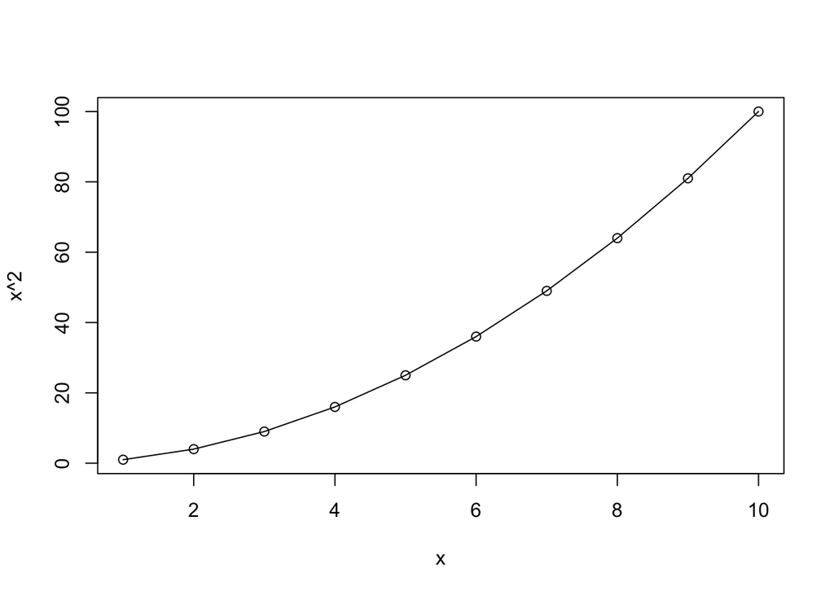

```r
plot(x, x^2, 'o')
```

Please complete all the tasks below by implementing code chunks that have a `TODO` comment in them, running all code chunks so that output and plots are displayed, and typing in answers to each question (**Q:** …) next to/below the corresponding answer prompt (**A:**). Feel free to add code chunks/show additional output to support any of the answers.

When you are done, you will need to submit the final R markdown file (as **pr1.Rmd**) with all code chunks implemented and executed, and all text responses written in. You also need to submit a PDF export of the markdown file (as **pr1.pdf**), which should show your code, output, plots and written responses–this will be your project report. Compress these two files into a single .zip archive and upload it on T-Square.

# Setup

## Load data

Make sure you’ve downloaded the [`movies_merged`](https://s3.amazonaws.com/content.udacity-data.com/courses/gt-cs6242/project/movies_merged) file and it is in the current working directory. Now load it into memory:

```r
load('movies_merged')
cat("Dataset has", dim(movies_merged)[1], "rows and", dim(movies_merged)[2], "columns", end="\n", file="")
```

```
Dataset has 40789 rows and 39 columns
```

This creates an object of the same name (`movies_merged`). For convenience, you can copy it to `df` and start using it:

```r
df = movies_merged
cat("Column names:", end="\n", file="")
```

```
Column names:
```

```r
colnames(df)
```

```
 [1] "Title"             "Year"              "Rated"
 [4] "Released"          "Runtime"           "Genre"
 [7] "Director"          "Writer"            "Actors"
[10] "Plot"              "Language"          "Country"
[13] "Awards"            "Poster"            "Metascore"
[16] "imdbRating"        "imdbVotes"         "imdbID"
[19] "Type"              "tomatoMeter"       "tomatoImage"
[22] "tomatoRating"      "tomatoReviews"     "tomatoFresh"
[25] "tomatoRotten"      "tomatoConsensus"   "tomatoUserMeter"
[28] "tomatoUserRating"  "tomatoUserReviews" "tomatoURL"
[31] "DVD"               "BoxOffice"         "Production"
[34] "Website"           "Response"          "Budget"
[37] "Domestic_Gross"    "Gross"             "Date"
```

[output not shown]

[output cut: 22 more lines]

[output not shown]

## Load R packages

Load any R packages that you will need to use. You can come back to this chunk, edit it and re-run to load any additional packages later.

```r
library(ggplot2)
library(GGally)

# Note that I'm using Anaconda R, and I was having trouble installing qdapTools. I'm not sure
# if this is the same on other machines but I did have to install R XML separately
# https://anaconda.org/r/r-xml
# conda install -c r r-xml. Only after could I install qdapTools.
library(qdapTools)
```

If you are loading any non-standard packages (ones that have not been discussed in class or explicitly allowed for this project), please mention them below. Include any special instructions if they cannot be installed using the regular `install.packages('<pkg name>')` command.

# Tasks

Each task below is worth **10** points, and is meant to be performed sequentially, i.e. do step 2 after you have processed the data as described in step 1. Total points: **100**

Complete each task by implementing code chunks as described by `TODO` comments, and by responding to questions (“**Q**:”) with written answers (“**A**:”). If you are unable to find a meaningful or strong relationship in any of the cases when requested, explain why not by referring to appropriate plots/statistics.

It is okay to handle missing values below by omission, but please omit as little as possible. It is worthwhile to invest in reusable and clear code as you may need to use it or modify it in project 2.

## 1. Remove non-movie rows

The variable `Type` captures whether the row is a movie, a TV series, or a game. Remove all rows from `df` that do not correspond to movies.

```r
# TODO: Remove all rows from df that do not correspond to movies
df2 <- df[df$Type == "movie",]
original_dim = dim(df)
new_dim = dim(df2)

df = df2
# Differences in rows
print(original_dim[1] - new_dim[1])
```

```
[1] 789
```

**Q**: How many rows are left after removal? *Enter your response below.*

**A**: The number of rows left after removal are 40000.

## 2. Process `Runtime` column

The variable `Runtime` represents the length of the title as a string. Write R code to convert it to a numeric value (in minutes) and replace `df$Runtime` with the new numeric column.

```r
extract_runtime = function(r){
    times = unlist(r)
    minutes = 0
    for (i in 1:length(times) - 1){
        if (times[i + 1] == 'h'){
            minutes = minutes + as.numeric(times[i]) * 60
        } else if (times[i + 1] == 'min'){
            minutes = minutes + as.numeric(times[i])
        }
    }
    if (minutes == 0){
        return(NA)
    } else{
        return(minutes)
    }
}

y=strsplit(df$Runtime,' ')
new_runtimes = unlist(lapply(y, extract_runtime))
df$Runtime = new_runtimes

cols = c('Runtime', 'Year', 'Budget')
summary(df[cols])
```

```
    Runtime            Year          Budget
 Min.   :  1.00   Min.   :1888   Min.   :     1100
 1st Qu.: 72.00   1st Qu.:1961   1st Qu.:  5000000
 Median : 90.00   Median :1989   Median : 18000000
 Mean   : 81.79   Mean   :1981   Mean   : 31661108
 3rd Qu.:101.00   3rd Qu.:2001   3rd Qu.: 40000000
 Max.   :873.00   Max.   :2018   Max.   :425000000
 NA's   :751                     NA's   :35442
```

Now investigate the distribution of `Runtime` values and how it changes over years (variable `Year`, which you can bucket into decades) and in relation to the budget (variable `Budget`). Include any plots that illustrate.

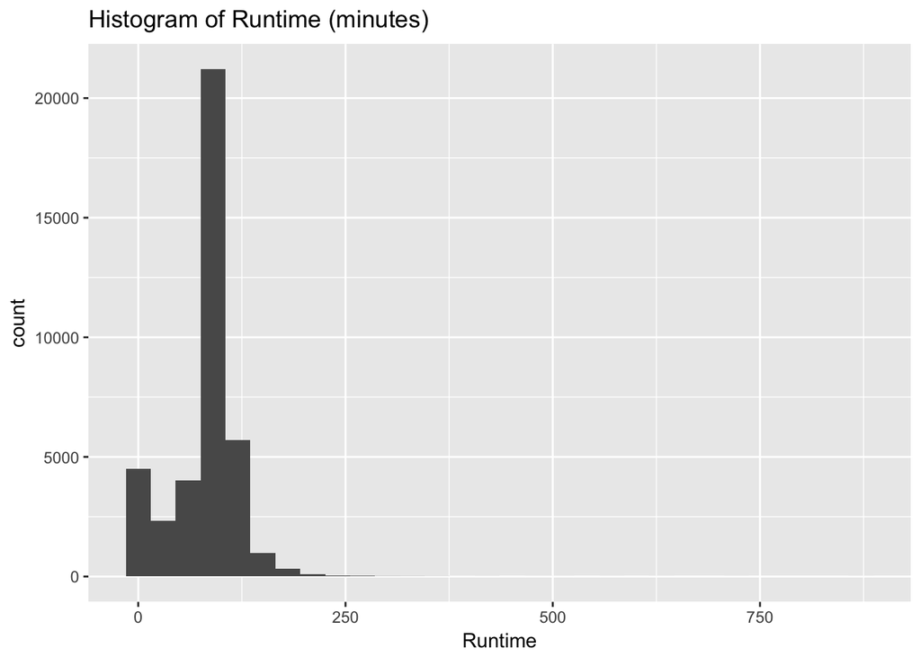

```r
# TODO: Investigate the distribution of Runtime values and how it varies by Year and Budget
ggplot(df, aes(x=Runtime)) +
  geom_histogram() +
  ggtitle('Histogram of Runtime (minutes)')
```

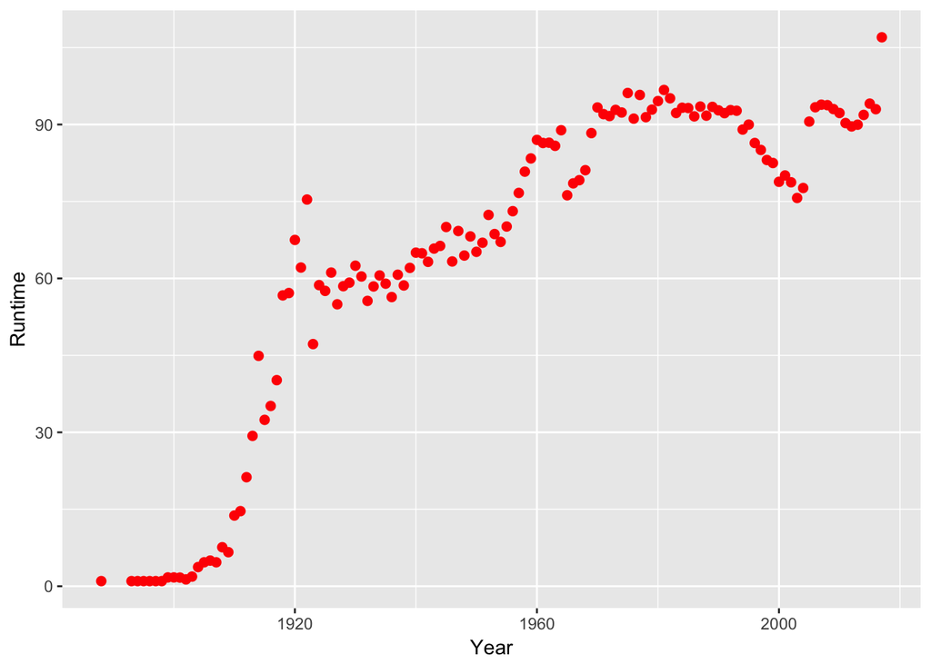

```r
ggplot(df, aes(Year, Runtime)) +
  stat_summary(fun.y = "mean", colour = "red", size = 2, geom = "point")
```

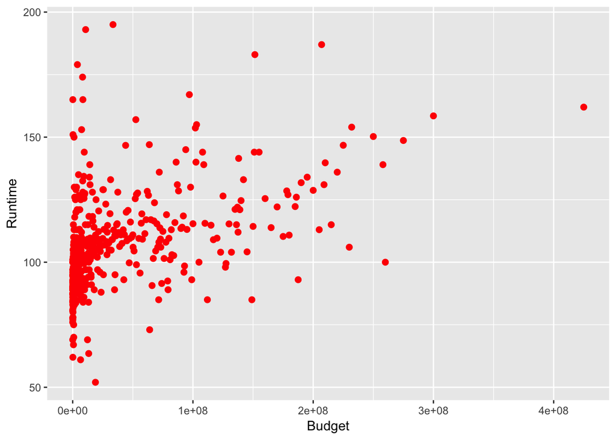

```r
ggplot(df, aes(Budget, Runtime)) +
  stat_summary(fun.y = "mean", colour = "red", size = 2, geom = "point")
```

*Feel free to insert additional code chunks as necessary.*

**Q**: Comment on the distribution as well as relationships. Are there any patterns or trends that you can observe?

**A**:

Looking in the aggregate, it seems like most runtimes are under 2 hours. There is a clear relationship between run time and year, looking a bit like a sigmoid function. This makes sense as very early years, it was probably technologically prohibitive to create long movies. As technology improved, runtimes increased, but there’s only so much time you can expect to hold an audience captive. Interestingly enough, during the 1990’s there seems to be a downward trend in runtimes until around mid 2000’s where it picked up again.